# Even More `ggplot2`

Jake Rozran

2022-02-08

Type `scale_` then click tab to see all of the options in a dropdown.

# Guides

The book wants you to use “guides” instead of “legends,” but let’s be real… everyone knows they are legends.

There is more to guide, however, than just legends. It should be clear what each aesthetic is and how to interpret it.

## Legends

In the last plot, I showed how to turn off a legend. The same configuration will change the position.

I tend to feel that a legend should be at the top of a plot. It is the first place eyes go when they read a plot.

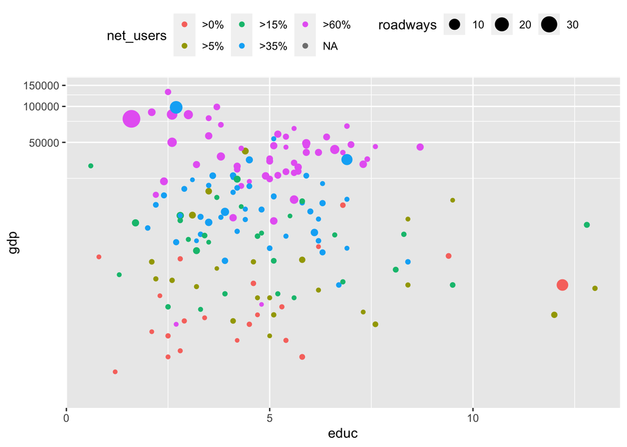

```r
ggplot(data = CIACountries, aes(x = educ, y = gdp)) +
    geom_point(aes(color = net_users, size = roadways)) +
    coord_trans(y = "log10") +
    theme(legend.position = "top") # Can be right, left, bottom, and top
```

## Titles

Legends aren’t the only guides, though. You must also be specific in your graph and axis titling. This is an easy way to add non-obtrusive information to your data visualization.

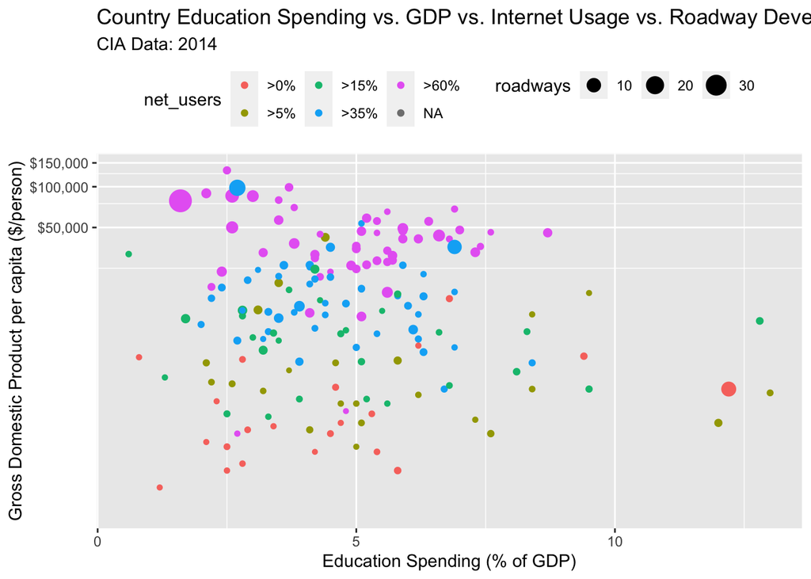

```r
ggplot(data = CIACountries, aes(x = educ, y = gdp)) +
    geom_point(aes(color = net_users, size = roadways)) +
    coord_trans(y = "log10") +
    scale_y_continuous(labels = scales::dollar) +
    theme(legend.position = "top") +
    ggtitle("Country Education Spending vs. GDP vs. Internet Usage vs. Roadway Development",
            subtitle = "CIA Data: 2014") +
    xlab("Education Spending (% of GDP)") +
    ylab("Gross Domestic Product per capita ($/person)")
```

## Labels & Text

This example graph likely has too many aesthetics, but let’s add more text to the graph to clear up which country is which.

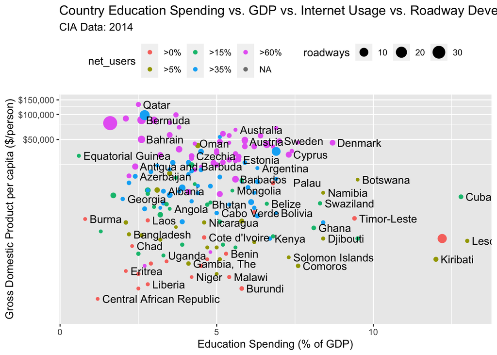

```r
ggplot(data = CIACountries, aes(x = educ, y = gdp)) +
    geom_point(aes(color = net_users, size = roadways)) +
    geom_text(aes(label = country),
              check_overlap = TRUE,
              nudge_x = 0.15,
              hjust = 0) +
    coord_trans(y = "log10") +
    scale_y_continuous(labels = scales::dollar) +
    theme(legend.position = "top") +
    ggtitle("Country Education Spending vs. GDP vs. Internet Usage vs. Roadway Development",
            subtitle = "CIA Data: 2014") +
    xlab("Education Spending (% of GDP)") +
    ylab("Gross Domestic Product per capita ($/person)")
```

This is too much… but… this is also just an example to show you all the things.

# Facets

When one plot has too much going on (see the last plot we made), it is sometimes a good idea to create separate plots for subsets of data. We call this faceting.

Be careful, though. It is now unclear what that facet means!

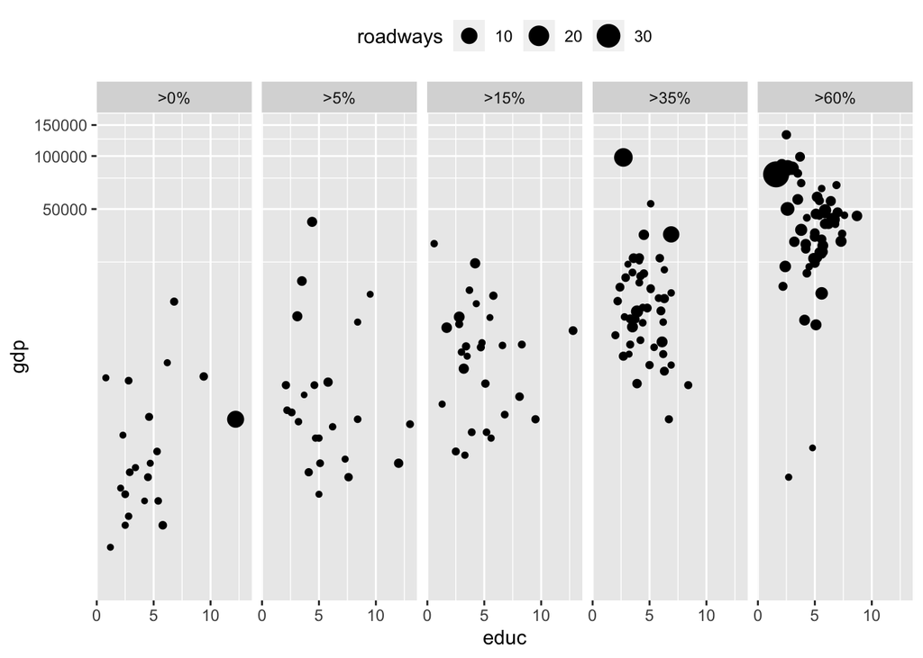

```r
ggplot(data = CIACountries[!is.na(CIACountries$net_users), ],
       aes(x = educ, y = gdp)) +
    geom_point(aes(size = roadways)) +
    coord_trans(y = "log10") +
    facet_wrap(~ net_users, nrow = 1) +
    theme(legend.position = "top")
```

We can also “lie” with facets (well… with the scales in a facet).

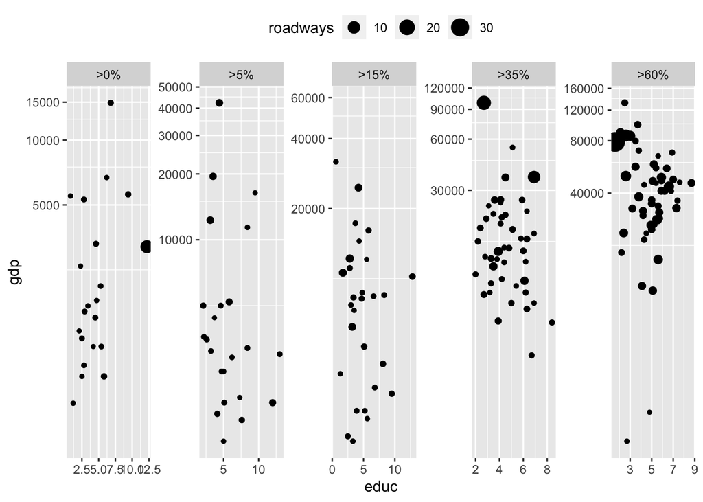

```r
ggplot(data = CIACountries[!is.na(CIACountries$net_users), ],
       aes(x = educ, y = gdp)) +
    geom_point(aes(size = roadways)) +
    coord_trans(y = "log10") +
    facet_wrap(~ net_users, nrow = 1, scales = "free") +
    theme(legend.position = "top")
```

It is not ALWAYS a bad idea to change the scale by facet, but this is way worse! Now you don’t see the nice relationship that popped up before.

# Layers

Just as the name implies, we can also add information by layering in data. We’ve done this in a very small way by layering in text before.

You can, though, layer multiple data viz.

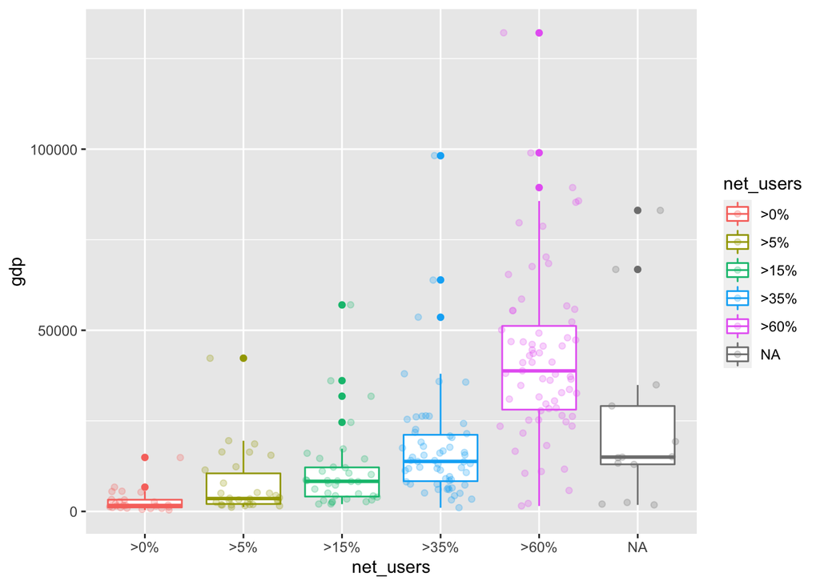

```r
ggplot(data = CIACountries,
       aes(x = net_users, y = gdp, group = net_users, color = net_users)) +
    geom_boxplot() +
    geom_jitter(alpha = 0.25)
```

Why do this? This shows the user how many countries are in each group!